# Web Scraping Assignment 2

Nawal Zehra Hasan

12/05/2021

Prompt: Find an api that returns with a JSON. You have to prove that you know how to deal with a list. Write a function(s) that process one batch of data and then move to the next data. (lapply, rbindlist). Show your data in table format(head is enough) and make a few(2-3) ggplot which will give some insight of your dataset.

```r
#cleaning the environment
rm(list = ls())
```

```r
#loading relevant libraries
library(jsonlite)
library(httr)
library(rvest)
library(data.table)
library(ggplot2)
library(tidyverse)
library(forcats)
```

ABOUT THE API

To complete this task, I chose the offical US Government’s source for fuel economy API information to scrape data. The API information can be found [*here*](https://www.fueleconomy.gov/feg/ws/). This was my choice as it gave a variety of options to choose from about vehicles such as vehicle make, fuel prices, emissions, model years and much more. I chose emissions for a few vehicle IDs(provided in the csv on the website) which returned a data frame with the variables listed below. This API was publicly available and anyone can access it without any sort of registration or private key/token.

Below is the meaning for each variable for Emissions dataframe that I will create using the API * EmissionsInfo * efid: engine family ID * id: vehicle record ID (links emission data to the vehicle record) * salesArea: EPA sales area code * score: EPA 1-10 smog rating for fuelType1 * scoreAlt: EPA 1-10 smog rating for fuelType2 * smartwayScore: SmartWay Code * standard: Vehicle Emission Standard Code * stdText: Vehicle Emission Standard

```r
#emission records for specific vehicle
#using base url
base_url <- 'https://www.fueleconomy.gov/ws/rest/'
#creating info url
info_url <- 'vehicle/emissions/'
#adding ID
id <- '40593'
full_url <- base::paste0(base_url, info_url, id)
#call the API
api_call <- GET(full_url)
api_call$status_code
Emissions_list <- fromJSON(rawToChar(api_call$content), flatten = TRUE)
df <- Emissions_list$emissionsInfo
df
```

[output not shown]

```r
#emission records for 4 vehicles
base_url <- 'https://www.fueleconomy.gov/ws/rest/'
info_url <- 'vehicle/emissions/'
ids <- c('41118','41090', '40638','19935')
full_url <- paste0(base_url, info_url, ids)
```

```r
#function to get multiple vehicles emissions
Call_api <- function(api){
  api_call <- GET(api)
  api_call$status_code
  Emissions_list <- fromJSON(rawToChar(api_call$content), flatten = TRUE)
  df <- Emissions_list$emissionsInfo
}
```

```r
#using lapply and rbind
df_list <-lapply(full_url,Call_api)
final_df <- rbindlist(df_list)
final_df
```

```
##             efid    id salesArea score scoreAlt smartwayScore  standard
##  1: KGMXT04.3186 41118         7   6.0     -1.0            -1  L3ULEV50
##  2: KGMXT04.3186 41118         3   6.0     -1.0            -1     T3B50
##  3: KMBXV04.0U2A 41090         7   3.0     -1.0            -1 L3ULEV125
##  4: KMBXV04.0U2A 41090         3   3.0     -1.0            -1    T3B125
##  5: KMBXV04.0U2A 41090         7   3.0     -1.0            -1    T3B125
##  6: KCRXJ02.05P2 40638         3   3.0     -1.0            -1    T3B110
##  7: 4FJXV02.5MJS 19935         3   5.0     -1.0            -1        B5
##  8: 4FJXV02.5MJS 19935         7   5.0     -1.0            -1        L2
##  9: 4FJXV02.5NKR 19935         3   5.0     -1.0            -1        B5
## 10: 4FJXV02.5NKR 19935         7   9.0     -1.0             1        S2
##                                 stdText
##  1:           California LEV-III ULEV50
##  2:               Federal Tier 3 Bin 50
##  3:          California LEV-III ULEV125
##  4:              Federal Tier 3 Bin 125
##  5:              Federal Tier 3 Bin 125
##  6: Federal Tier 3 Transitional Bin 110
##  7:                               BIN 5
##  8:                              LEV II
##  9:                               BIN 5
## 10:                        LEV-II SULEV
```

```r
head(final_df)
```

```
##            efid    id salesArea score scoreAlt smartwayScore  standard
## 1: KGMXT04.3186 41118         7   6.0     -1.0            -1  L3ULEV50
## 2: KGMXT04.3186 41118         3   6.0     -1.0            -1     T3B50
## 3: KMBXV04.0U2A 41090         7   3.0     -1.0            -1 L3ULEV125
## 4: KMBXV04.0U2A 41090         3   3.0     -1.0            -1    T3B125
## 5: KMBXV04.0U2A 41090         7   3.0     -1.0            -1    T3B125
## 6: KCRXJ02.05P2 40638         3   3.0     -1.0            -1    T3B110
##                                stdText
## 1:           California LEV-III ULEV50
## 2:               Federal Tier 3 Bin 50
## 3:          California LEV-III ULEV125
## 4:              Federal Tier 3 Bin 125
## 5:              Federal Tier 3 Bin 125
## 6: Federal Tier 3 Transitional Bin 110
```

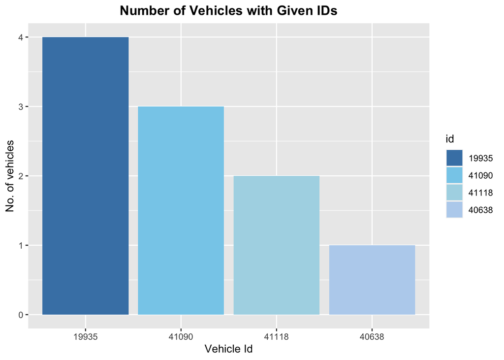

```r
#Visualizations

#no. of vehicles with given IDs
v1 <- ggplot(final_df, aes(x= fct_infreq(id), fill = id)) +
  geom_bar() +
  xlab('Vehicle Id') +
  ylab('No. of vehicles') +
  ggtitle('Number of Vehicles with Given IDs') +
  scale_fill_manual(values = c("19935" = "steelblue",
                               "41090" =  "skyblue",
                               "41118" = "lightblue",
                               "40638" = "slategray2"))+
   theme(plot.title = element_text(face = "bold", hjust = 0.5))
v1
```

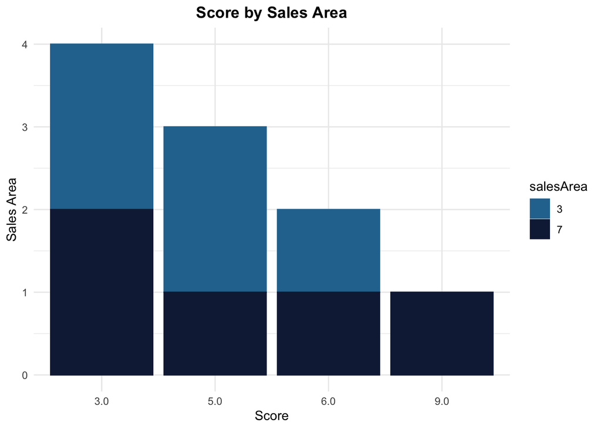

```r
#Emissions Score by Sales Area
v2 <- ggplot(final_df) +
  aes(x = score, fill = salesArea, colour = salesArea) +
  geom_bar() +
  scale_fill_manual(
    values = c(`3` = "#29749E",
               `7` = "#122243")) +
  scale_color_manual(
    values = c(`3` = "#29749E",
               `7` = "#122243")) +
    xlab("Score") +
    ylab("Sales Area")  +
    ggtitle("Score by Sales Area") +
  theme_minimal() +
  theme(plot.title = element_text(face = "bold", hjust = 0.5))
v2
```